# Statistical Analysis for: Matrisome alterations in obesity - Adipose tissue transcriptome study on monozygotic weight-discordant twins

### Library Used

```r
#General Bioconductor packages
library(Biobase)
library(oligoClasses)

#Annotation and data import packages
library(ArrayExpress)
library(pd.hg.u133.plus.2)
library(biomaRt)

#Quality control and pre-processing packages
library(oligo)
library(arrayQualityMetrics)

#Analysis and statistics packages
library(limma)

#Plotting and color options packages
library(gplots)
library(ggplot2)
library(RColorBrewer)

#Formatting/documentation packages
library(dplyr)
library(tidyr)

#Helpers:
library(openxlsx)
library(readxl, writexl)
```

# Data Preparation

In order to follow the pipeline for the analysis, the genomic data must be formatted to fit into an ExpressionSet class from Bioconductor. The class includes and assay data, a feature data, and a phenotypic meta-data. Assay data and phenotype data come from the Finnish project while the feature data is generated with the biomaRT library.

```r
### Load adipose tissue gene
adipose_tissue_gene <- read_excel(paste(wdir, "/Datasets/MZtwins_whole genome_adipocyte_adipose tissue.xlsx", sep = ""),
                                  sheet = "Adipose Tissue", skip = 4, col_names = FALSE)
```

## Phenotype Data

```r
# Family ID
fid <- paste0('fam', c('A','B','C','D','E','F','G','H','I','J','K','L','M','N','O','P','Q','R','S','T','U','V','W','X','Y',
                      'A','B','C','D','E','F','G','H','I','J','K','L','M','N','O','P','Q','R','S','T','U','V','W','X','Y'))
fid <- as.factor(fid)

# Individual ID
pid <- paste0('ind', c(1,2,3,4,5,6,7,8,9,10,11,12,13,14,15,16,17,18,19,20,21,22,23,24,25,26,
                      27,28,29,30,31,32,33,34,35,36,37,38,39,40,41,42,43,44,45,46,47,48,49,50))
pid <- as.factor(pid)

# Group (lean and heavy)
group <- as.factor(rep(c('lean','heavy'), each=length(pid)/2))

# Create phenotype data
adipose_tissue_phenoData <- data.frame(fid, pid, group)

write.csv(adipose_tissue_phenoData, file = paste(wdir, "/Datasets/adipose_tissue_phenoData.csv", sep=""),
          row.names = FALSE)
```

## Assay Data

```r
# Create assay data
adipose_tissue_assayData <- as.data.frame(adipose_tissue_gene[, -c(1, 2)])

rownames(adipose_tissue_assayData) <- make.names(adipose_tissue_gene[[1]], unique=TRUE)
colnames(adipose_tissue_assayData) <- paste(adipose_tissue_phenoData$fid, adipose_tissue_phenoData$pid, sep=".")

write.csv(adipose_tissue_assayData, file = paste(wdir, "/Datasets/adipose_tissue_assayData.csv", sep=""),
          row.names = TRUE)
```

## Feature Data

```r
### Try to get the annotation data
mart <- useMart(biomart = "ENSEMBL_MART_ENSEMBL", dataset="hsapiens_gene_ensembl")
annotations <- getBM(
  attributes=c(
    'hgnc_symbol',
    "ensembl_gene_id",
    'description',
    "external_gene_name",
    'gene_biotype',
    'chromosome_name',
    "affy_hg_u133_plus_2"
  ),
  filters = 'hgnc_symbol', values = rownames(adipose_tissue_assayData), mart = mart, uniqueRows=TRUE)
```

```r
annotations <- annotations[match(rownames(adipose_tissue_assayData), annotations$hgnc_symbol), ]


### Get the additional information for each individual
adipose_tissue_featureData <- data.frame(geneId = as.factor(adipose_tissue_gene[[1]]),
                                        geneDesc = as.factor(adipose_tissue_gene[[2]]))

write.csv(annotations, file = paste(wdir, "/Datasets/adipose_tissue_featureData.csv", sep=""),
          row.names = FALSE)
```

## Create ExpressionSet

```r
assayData <- read.csv(paste(wdir, "/Datasets/adipose_tissue_assayData.csv", sep=""), row.names=1)
assayData <- as.matrix(assayData)

adipose_tissue_phenoData <- read.csv(paste(wdir, "/Datasets/adipose_tissue_phenoData.csv", sep=""))
rownames(adipose_tissue_phenoData) = colnames(assayData)

metadata <- data.frame(labelDescription=
                         c("Family Id",
                           "Individual Id",
                           "Case/control status"),
                       row.names=c("fid", "pid", "group"))

phenoData <- new("AnnotatedDataFrame", data=adipose_tissue_phenoData, varMetadata=metadata)
adipose_tissue_featureData <- read.csv(paste(wdir, "/Datasets/adipose_tissue_featureData.csv", sep=""))
rownames(adipose_tissue_featureData) = rownames(assayData)
featureData <- new("AnnotatedDataFrame", data=adipose_tissue_featureData)

raw_data  <- new("ExpressionSet", exprs = assayData, phenoData = phenoData,
                 featureData = featureData,
                 annotation="pd.hg.u133.plus.2")
```

# Data Preprocessing

### Normalization

The data was normalized and filtered. Normalization of the data was performed using the corresponding function from the Oligo library.

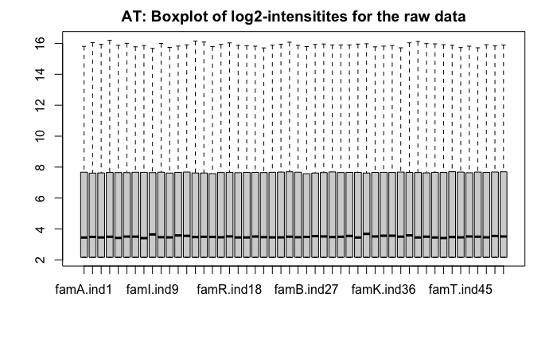

```r
oligo::boxplot(raw_data, target = "core",
               main = "AT: Boxplot of log2-intensitites for the raw data")
```

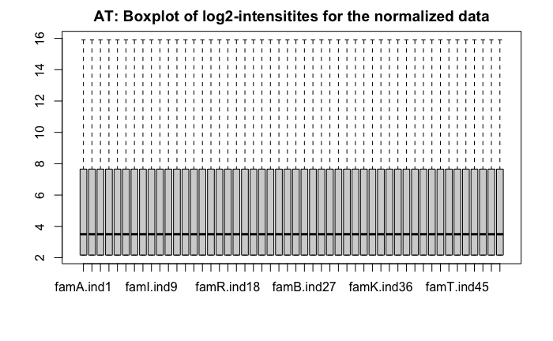

```r
palmieri_eset_norm <- oligo::normalize(raw_data)

oligo::boxplot(palmieri_eset_norm, target = "core",
               main = "AT: Boxplot of log2-intensitites for the normalized data")
```

### Filtering

The data was filtered using a threshold value of 3. Transcripts that do not have intensities larger than the threshold in at least as many arrays as the smallest experimental group were excluded.

```r
par(mfrow=c(2,1))

palmieri_medians <- rowMedians(Biobase::exprs(palmieri_eset_norm))

man_threshold <- 3

hist_res <- hist(palmieri_medians, 100, col = "cornsilk", freq = FALSE,
                 main = "AT: Histogram of the median intensities of unfiltered expression data",
                 border = "antiquewhite4",
                 xlab = "Median intensities")

abline(v = man_threshold, col = "coral4", lwd = 2)
```

[figure not shown]

```r
no_of_samples <- table(pData(palmieri_eset_norm)$group)
samples_cutoff <- min(no_of_samples)

idx_man_threshold <- apply(Biobase::exprs(palmieri_eset_norm), 1,
                           function(x){
                             sum(x > man_threshold) >= samples_cutoff})

palmieri_manfiltered <- subset(palmieri_eset_norm, idx_man_threshold)

hist(rowMedians(Biobase::exprs(palmieri_manfiltered)), 100, col = "cornsilk", freq = FALSE,
     main = "AT: Histogram of the median intensities of filtered expression data",
     border = "antiquewhite4",
     xlab = "Median intensities")
```

[output not shown]

# Hypothesis Testing

Regression analysis was performed, and hypothesis testing followed.

### Design Matrix

```r
fam <- as.character(Biobase::pData(palmieri_manfiltered)$fid)
group <- Biobase::pData(palmieri_manfiltered)$group

design <- model.matrix(~ 0 + group + fam)
rownames(design) <- Biobase::pData(palmieri_manfiltered)$pid
```

### Contrast Matrix

```r
contrast_matrix <- makeContrasts(groupheavy - grouplean, levels = design)
```

### Model Fit

*voom* function adjusts the data for heteroscedasticity and prepares the data for linear fit. The design and contrast matrices were fit in a linear model using the corresponding function from the limma library. Empirical Bayes method was used to make more precise estimates of gene-wise variability and to get moderated results.

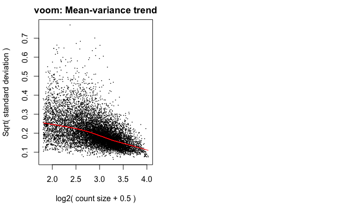

```r
par(mfrow=c(1,2))

v <- voom(palmieri_manfiltered, design, plot=TRUE)

vfit <- lmFit(v, design)

contrastfit <- contrasts.fit(vfit, contrasts=contrast_matrix)
efit <- eBayes(contrastfit)
plotSA(efit, main="AT: Final model: Mean-variance trend")
```

[output not shown]

# Results

Significance of the differential expression of each genes was extracted using the function topTable on the linear model fit. The adjusted p-value is derived from the Benjamini-Hochberg Procedure, which decreases the false discovery rate.

```r
table_adipose <- topTable(efit, number = Inf, sort.by = "p")
head(table_adipose)
```

|  | hgnc_symbol | ensembl_gene_id | description | external_gene_name | gene_biotype | chromosome_name | affy_hg_u133_plus_2 | logFC | AveExpr | t | P.Value | adj.P.Val | B |
| --- | --- | --- | --- | --- | --- | --- | --- | --- | --- | --- | --- | --- | --- |
| EIF4EBP1 | EIF4EBP1 | ENSG00000187840 | eukaryotic translation initiation factor 4E binding protein 1 [Source:HGNC Symbol;Acc:HGNC:3288] | EIF4EBP1 | protein_coding | 8 | 221539_at | -0.11138501 | 6.765151 | -8.769797 | 2.606702e-09 | 1.651649e-05 | 11.326696 |
| RFC1 | RFC1 | ENSG00000035928 | replication factor C subunit 1 [Source:HGNC Symbol;Acc:HGNC:9969] | RFC1 | protein_coding | 4 | 209085_x_at | -0.03856330 | 6.885305 | -8.503285 | 4.797782e-09 | 1.651649e-05 | 10.630473 |
| HSD11B1 | HSD11B1 | ENSG00000117594 | hydroxysteroid 11-beta dehydrogenase 1 [Source:HGNC Symbol;Acc:HGNC:5208] | HSD11B1 | protein_coding | 1 |  | 0.14656254 | 7.026956 | 8.396453 | 6.143186e-09 | 1.651649e-05 | 10.175650 |
| ITGB5 | ITGB5 | ENSG00000082781 | integrin subunit beta 5 [Source:HGNC Symbol;Acc:HGNC:6160] | ITGB5 | protein_coding | 3 | 201124_at | 0.05735242 | 7.178329 | 8.374971 | 6.457430e-09 | 1.651649e-05 | 10.097018 |
| FTH1 | FTH1 | ENSG00000167996 | ferritin heavy chain 1 [Source:HGNC Symbol;Acc:HGNC:3976] | FTH1 | protein_coding | 11 |  | 0.06204471 | 7.350841 | 8.232172 | 9.010635e-09 | 1.843756e-05 | 9.597420 |
| STK38L | STK38L | ENSG00000211455 | serine/threonine kinase 38 like [Source:HGNC Symbol;Acc:HGNC:17848] | STK38L | protein_coding | 12 |  | 0.05600613 | 6.932920 | 7.806979 | 2.468921e-08 | 4.209922e-05 | 8.955166 |

```r
dt <- decideTests(efit)
summary(dt)
```

```
       groupheavy - grouplean
Down                     1575
NotSig                   7334
Up                       1322
```

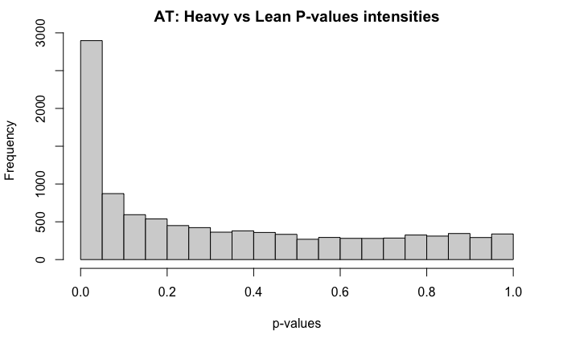

```r
hist(table_adipose$adj.P.Val, main = "AT: Heavy vs Lean P-values intensities", xlab = "p-values")
```

### Finding P-values

```r
signif_genes <- rownames(as.matrix(dt[dt != 0,]))
signif_toptable <- table_adipose[rownames(table_adipose) %in% signif_genes,]

## P-value
pval_min <- min(table_adipose$P.Value)
pval_max <- max(table_adipose$P.Value)

pval_cutoff <- max(signif_toptable$P.Value)

## Adjusted P-value
adjPval_min <- min(table_adipose$adj.P.Val)
adjPval_max <- max(table_adipose$adj.P.Val)

adjPval_cutoff <- max(signif_toptable$adj.P.Val)
```